# CRCJ 3350-Criminology

# Introductions

# I’m Nick!

A PhD Candidate in the College of Criminology and Criminal Justice at UNO.

**Research Interests:** Biopsychosocial criminology and quantitative methods

**Teaching Interests:** Research methods and statistics

**Where I’m from:** Detroit, Michigan

**Fun fact:** I’m a Detroit Lion’s fan 😭

# Your turn!

**Your name?**

**Where you’re from?**

**Year and Career Interests?**

**Fun fact?**

# Syllabus

Tues., Thurs. / 10:00 AM – 11:15 AM / CPACS 222

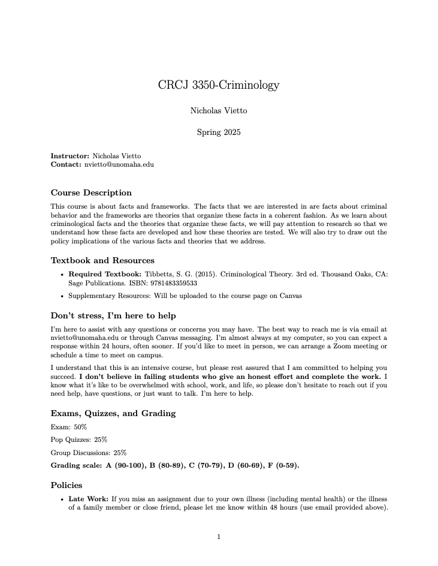

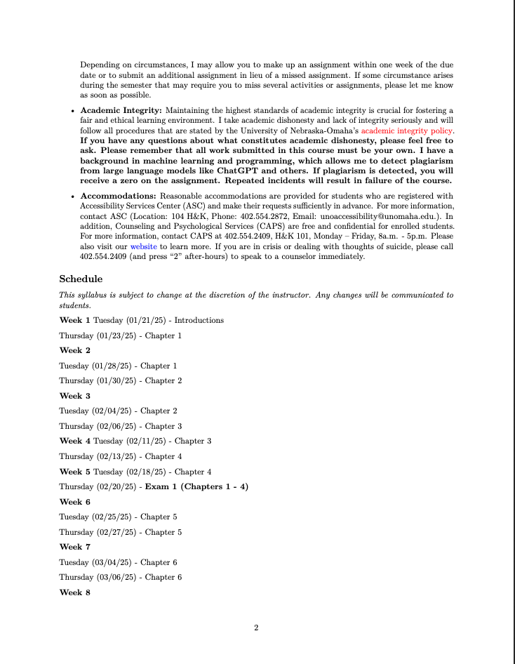

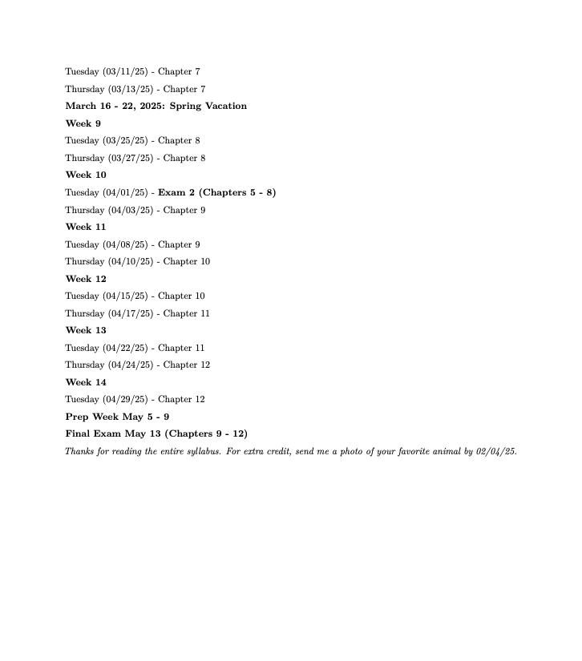

## Class Structure

- Slides will be available on Canvas (Files/Lecture Slides) after we cover each chapter.
- Everything you *need* to know is **not** in the slides
- Each lecture will be conducted with open discussion and participation is expected.
- We will have group discussion ~ 2 times a chapter!

## How will you be Graded?

- Exams (multiple-choice and writing) (50%)
- Pop Quizzes (multiple-choice) (25%)
- Discussion Groups (25%)
- Hint: if you see something in color in a lecture slide, it’s likely important to your exam

## My Expectations

- **Read**
- **Show up to class**
  - This material is cumulative (i.e., it snowballs) and missing lectures will impede your understanding of the material
  - If missing class is unavoidable, let me know.
- **Participate**

## Participation & Climate

- Inclusive environment
  - This class can & should be a place for *active* discussions. This is where learning ‘comes to life.’
- Consider the discussion ‘space’ you take up
  - Allow others to speak.
    - If you find yourself taking up most of the discussion, take a break & give room for others to participate.
  - This space is for all of us.

## Office Hours

- A couple options:
  - Talk to me after class
  - We can set up a time on Zoom

## Technology in the Classroom

Attention is Key

Learning requires intense focus. Concentrating without distractions strengthens specific brain circuits, which helps solidify skills.

Engaging in multitasking or ‘task switching’ can hinder learning by overloading your brain with competing stimuli.

Note-Taking Practices

While computers are permitted for note-taking, I strongly encourage using a notebook. Handwriting notes can enhance focus and retention.

Device Etiquette

Phones should be turned off or kept in your bag during lectures to avoid distractions.

During group discussions, neither computers nor phones will be allowed to ensure active participation and engagement.

## Questions?

[figure not shown]

image: giphy